# Actividad 1

2025-08-21

## Equipo 9

### Problema a responder:

### El nivel de ingreso de las mujeres de la RM ¿varía con el estado civil?

Descripción de Variables

| Nombre | Tipo | Descripción |
| --- | --- | --- |
| folio | categórica, nominal | Identificador único del hogar |
| o | numérica, discreta | Número de orden de la persona dentro del hogar |
| id.vivienda | categórica, nominal | Identificador único de la vivienda |
| hogar | categórica, nominal | Identificación del hogar dentro de la vivienda |
| region | categórica, nominal | Región geográfica donde se encuentra el hogar |
| provincia | categórica, nominal | Provincia donde se encuentra el hogar |
| comuna | categórica, nominal | Comuna donde se encuentra el hogar |
| ing.comuna | numérica, discreta | Posición en ranking histórico de ingreso de la comuna (ascendente) |
| zona | categórica, nominal | Área geográfica (Urbano/Rural) |
| sexo | categórica, nominal | Sexo de la persona registrada |
| edad | numérica, discreta | Edad de la persona registrada en años |
| ecivil | categórica, nominal | Estado civil de la persona registrada |
| ch1 | categórica, nominal | Situación ocupacional de la persona registrada |
| ytot | numérica, discreta | Ingreso total de la persona |

#### Para realizar el análisis se usarán las variables región, sexo, ecivil y ytot. Puesto que con esto se cubre el

#### perfil objetivo a ver.

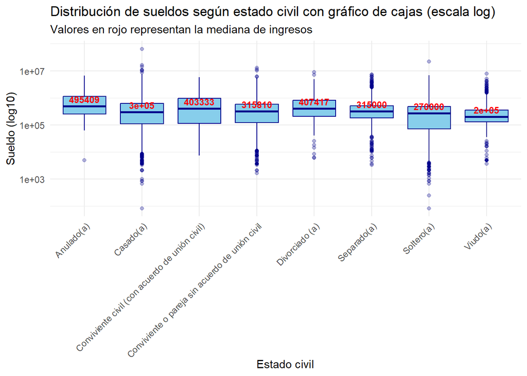

#### Esta variabilidad intergrupal sugiere que el estado civil se encuentra correlacionado con diferencias sustanciales en la distribución de ingresos. Si bien este análisis no permite establecer una relación causal, los patrones observados indican que el estatus marital actúa como un marcador asociado a otros factores subyacentes —como la edad, la experiencia laboral acumulada y las responsabilidades familiares— que en conjunto influyen en la realidad económica de los individuos.